# aula6 slides

[figure not shown]

## Algumas referências bibliográficas

- Frery, A. e Cribari-Neto, F. (2011) [Elementos de Estatística Computacional Usando Plataformas de Software Livre/Gratuito](https://impa.br/wp-content/uploads/2017/04/PM_21.pdf). 2a impressão. IMPA.
- Peng, R. [Advanced Statistical Computing](https://bookdown.org/rdpeng/advstatcomp/), úlma atualização em 2021-01-26.
- Devroye, L. (1986) [Non-Uniform Random Variate Generation](http://www.eirene.de/Devroye.pdf), New York: Springer-Verlag.

# Geração de números pseudo-aleatórios não-uniformes

### Distribuição uniforme

$\begin{aligned} f(u)&=\begin{cases}1, & \text{ para } u\in(0,1);\\ 0, & \text{ em caso contrário}\end{cases}\\ F(u)&=\mathbb{P}\left[U\le u\right]=u\\ \mathbb{E}[U]&=\frac12 \qquad \mathrm{var}[U]=\frac{1}{12} \end{aligned}$

[figure not shown]

### Geradores de números pseudo-aleatórios não-uniformes

Existem cenários específicos em que resulta necessário avaliar eventos que envolvem variáveis aleatórias que obedecem outras distribuições de probabilidade, além da uniforme. Um método universal, que utiliza variáveis aleatórias com distribuição uniforme em $(0, 1)$ é o método da função de distribuição acumulada inversa.

### Geradores de números pseudo-aleatórios não-uniformes

**Por exemplo**: Suponha $X$ uma variável aleatória continua, com função de distribuição acumulada monotona e continua, cuja inversa é denotada por $F^{-1}$. Se $U$ é uma variável aleatória uniforma no intervalo $(0,1)$ e $X=F^{-1}(U)$, então

$\begin{aligned} \mathbb{P}\left[X\le x\right]&=\mathbb{P}\left[F^{-1}(U)\le x\right]=\mathbb{P}\left[F\left(F^{-1}(U)\right)\le F(x)\right]\\ &=\mathbb{P}\left[U\le F(x)\right]=F(x)\quad\blacksquare \end{aligned}$

### Alguns exemplos

- **Deseja-se obter ocorrências de variáveis aleatórias uniformes no intervalo $(a, b)$, com $a < b$**

A distribuição da variável aleatória $X$, uniforme no intervalo $(a,b)$ é caracterizada pela função de distribuição acumulada $F(x) = \frac{x − a}{b−a}\mathbb{I}_{(a,b)}(x) + \mathbb{I}_{[b,\infty)}(x)$. Assim sendo, $X = (b − a)U + a$ terá a distribuição desejada quando $U$ for uniforme no intervalo $(0,1)$.

```r
# Geração de de números pseudo-aleatórios uniforme em (a, b)
uniform.random<-function(n,a=0,b=1){
    replicate(n,(b-a)*runif(1)+a)
}

uniform.random(n=20,a=10,b=50)
```

1. 11.161879170686

2. 29.3135639932007

3. 22.4981036689132

4. 40.1728854235262

5. 44.8370702005923

6. 45.7409322913736

7. 28.2722803298384

8. 32.8909673448652

9. 14.4157029036433

10. 33.0550455767661

11. 22.9641139972955

12. 47.351792678237

13. 23.3175931032747

14. 13.0334045272321

15. 18.7456196919084

16. 20.0913326628506

17. 11.1644145380706

18. 40.2435740362853

19. 43.6083227582276

20. 22.7586070075631

### Alguns exemplos

- **Deseja-se obter ocorrências de variáveis aleatórias Bernoulli com probabilidade $p$**

Use a transformação $X=\mathbb{I}_{1-U\le p}(u)$, onde $U$ for uniforme no intervalo $(0,1)$.

```r
# Geração de de números pseudo-aleatórios Bernoulli(p)

bernoulli.random<-function(n,p=0.5){
    sample<-function(p){
        x<-ifelse(runif(1)<=p,1,0)
    }
    replicate(n,sample(p))
}

bernoulli.random(n=20,p=0.1)
```

1. 0

2. 0

3. 0

4. 1

5. 0

6. 0

7. 0

8. 0

9. 0

10. 0

11. 0

12. 0

13. 0

14. 1

15. 0

16. 0

17. 0

18. 0

19. 0

20. 0

### Alguns exemplos

- **Deseja-se obter ocorrências de variáveis aleatórias exponenciais com parâmetro $1$**

Use a seguinte transformação $X = -\log(1-U)$, onde $U$ é uniforme no intervalo $(0,1)$.

```r
exponencial.random<-function(n){
    replicate(n,-log(runif(1)))
}

exponencial.random(n=200)
```

1. 0.226726538915368

2. 0.418634290083291

3. 0.271417415084291

4. 0.878390889956605

5. 0.581798657536449

6. 0.149683345010411

7. 2.12020865083127

8. 0.844756648259646

9. 0.857585254251162

10. 0.167386828802108

11. 0.202083814014146

12. 0.815807129937494

13. 0.238596627305788

14. 0.0349216041753348

15. 2.18326058633143

16. 0.628801632740269

17. 0.118145409215861

18. 1.61843422767487

19. 1.07234535359788

20. 0.0716322150515811

21. 2.40682615874805

22. 0.0108270577806936

23. 2.56379372701602

24. 1.71857849524293

25. 1.97410755267594

26. 1.80481559644178

27. 1.57419171494657

28. 0.505817020179645

29. 0.1106669700095

30. 0.108344502604887

31. 0.489471083634735

32. 0.919657005718623

33. 0.41892711658621

34. 0.61352410554906

35. 2.32143459468535

36. 0.727078560566074

37. 1.13923596513957

38. 2.45285468237808

39. 1.11667553895627

40. 0.521082860387178

41. 0.0657194390387506

42. 1.81803622338608

43. 0.917851779596849

44. 0.653773331158924

45. 1.01287801151251

46. 1.84529777103674

47. 0.657461865086133

48. 0.266930673894778

49. 1.55645573139136

50. 0.689569411647187

51. 0.202810345476346

52. 1.28865871413878

53. 0.21969146056675

54. 0.526274798823463

55. 2.76954815931411

56. 1.25010854513747

57. 0.215904570069806

58. 1.31891623908864

59. 0.733124742626821

60. 0.428913756789619

61. 0.0478048765027273

62. 0.743917024184916

63. 0.748964613289244

64. 0.389388873526335

65. 0.860046897383181

66. 0.0877630677633639

67. 1.22111400621779

68. 1.28786144420745

69. 0.380508235038117

70. 0.908353533884858

71. 0.00981475264401773

72. 0.0188657684383971

73. 0.0626503927353631

74. 0.381933475346006

75. 0.608902198812145

76. 0.699230052695665

77. 1.96610518370124

78. 0.943922577180189

79. 2.71525473080754

80. 3.84375596339076

81. 0.337301373159779

82. 0.138589115265283

83. 0.762605913699215

84. 0.455219533085861

85. 0.568528603641578

86. 0.232053329455334

87. 0.684715985720663

88. 1.32991817708833

89. 0.17088464059334

90. 0.12430436336741

91. 0.204725305459163

92. 0.324819989779359

93. 0.416710373620479

94. 0.304236441181472

95. 0.108433080773091

96. 0.382308877593225

97. 0.241321609165672

98. 1.43536453788995

99. 1.67227675359217

100. 0.32339987767217

101. 0.234784506254445

102. 0.317204709201528

103. 0.0975133061566196

104. 0.130287803546236

105. 3.84459510497282

106. 1.15685547227516

107. 0.0742566941861425

108. 0.561414632016481

109. 0.557164657331612

110. 1.12962642938502

111. 0.158451364824076

112. 0.809440249465792

113. 0.360504363505407

114. 0.360966974816341

115. 0.926372856798255

116. 0.486753774342735

117. 0.0895352736327191

118. 1.36997080802457

119. 0.323273538285415

120. 2.83077820019646

121. 2.23913151851329

122. 0.0485543791954315

123. 0.923651189872733

124. 0.219936774706122

125. 0.411120188446764

126. 1.32307825746476

127. 1.24580749760368

128. 0.236955744037328

129. 0.101249653379369

130. 0.0262321555444588

131. 0.168655692803592

132. 0.512068112434971

133. 0.45586309232685

134. 0.985164667344988

135. 0.476591393856422

136. 1.26746478110269

137. 0.818564117152381

138. 0.065094896496577

139. 4.52591494298324

140. 0.374390648831318

141. 1.50782017914191

142. 0.831854996837167

143. 2.96937695648338

144. 0.0197853345689719

145. 0.981899522165591

146. 0.106307432671133

147. 0.157420493870142

148. 0.0575934623709593

149. 0.120820341783804

150. 0.74471393128917

151. 2.81932219601844

152. 1.45802197300017

153. 0.0696421019179788

154. 0.679551960000682

155. 0.0539132244793076

156. 0.133853473747732

157. 0.121661236113975

158. 2.71261588973161

159. 0.00744098683759349

160. 0.959478529187568

161. 3.36470247435605

162. 0.920758573685152

163. 0.338968275218868

164. 0.446537337906173

165. 0.452394124938341

166. 0.259585881350327

167. 2.33145776202993

168. 0.652439995795275

169. 0.387745607570449

170. 0.146815174970718

171. 0.957131041762713

172. 0.101618159803259

173. 1.55662282125682

174. 0.545256900934947

175. 1.16688428274417

176. 0.409734654093415

177. 0.945089171145843

178. 0.660590776487134

179. 1.43138192108194

180. 0.0449934767352271

181. 0.228099561822075

182. 0.370649144955749

183. 0.0408243022529464

184. 0.892284952428582

185. 0.342095300641248

186. 0.796970871563071

187. 1.71341313933405

188. 0.157772167429977

189. 0.405165641242661

190. 1.39674963593628

191. 1.04567890647203

192. 0.26827030309507

193. 3.42230177093417

194. 1.79894578227573

195. 0.00433082487780348

196. 1.67675736659101

197. 1.28813492626775

198. 0.429364828021834

199. 0.081474144969524

200. 0.0605386291373279

### Alguns exemplos

- **Deseja-se obter ocorrências de variáveis aleatórias geométricas com parâmetro $p$**

Use a seguinte transformação $X = \left\lfloor\frac{\log(1-U)}{\log(1-p)}\right\rfloor$, onde $U$ é uniforme no intervalo $(0,1)$.

```r
geometric.random<-function(n,p){
    replicate(n,floor(log(runif(1)) / log(1-p)))
}

geometric.random(n=20,p=0.3)
```

1. 7

2. 1

3. 2

4. 1

5. 2

6. 1

7. 0

8. 0

9. 7

10. 0

11. 1

12. 1

13. 0

14. 3

15. 1

16. 0

17. 3

18. 1

19. 0

20. 7

### Outros exemplos

- **Cauchy padrão**: $X = \tan(\pi(U−1/2))$, onde $U$ é uniforme no intervalo $(0,1)$;
- **Weibull($\sigma,k$)**: $X = \sigma(-\log(1-U))^{1/k}$, onde $U$ é uniforme no intervalo $(0,1)$;
- **Gumbel($\mu,\sigma$)**: $X = -\log(-\log U)$, onde $U$ é uniforme no intervalo $(0,1)$;

### Outros exemplos

- **Beta simétrica($\alpha,\alpha$)**: $X =\frac12\left(1+\sqrt{1-U_1^{\frac{2}{2\alpha-1}}}\cos(2\pi U_2)\right)$, onde $U_1$ e $U_2$ são uniformes no intervalo $(0,1)$;
- $t_{(n)}$: $X =\sqrt{n\left(U_1^{-2/n}-1\right)}\cos(2\pi U_2)$, onde $U_1$ e $U_2$ são uniformes no intervalo $(0,1)$.

### Outros exemplos

- Para o caso de valores pseudo-aleatórios normais padrão use $X=\sqrt{-2\log U_1}\cos(2\pi U_2)$ e $Y=\sqrt{-2\log U_2}\sin(2\pi U_1)$, onde $U_1$ e $U_2$ são uniformes no intervalo $(0,1)$.

No `R` use as seguintes funções

| Distribuição | função de distribuição acumulada | número pseudo aleatórios | Parâmetros |
| --- | --- | --- | --- |
| `beta` | `pbeta` | `rbeta` | `shape1`, `shape2` |
| `binomial` | `pbinom` | `rbinom` | `size`, `prob` |
| `chi-squared` | `pchisq` | `rchisq` | `df` |
| `exponential` | `pexp` | `rexp` | `rate` |
| `F` | `pf` | `rf` | `shape`, `scale` |
| `gamma` | `pgamma` | `rgamma` | `size`, `prob` |
| `geometric` | `pgeom` | `rgeom` | `prob` |

No `R` use as seguintes funções

| Distribuição | função de distribuição acumulada | número pseudo aleatórios | Parâmetros |
| --- | --- | --- | --- |
| `lognormal` | `plnorm` | `rlnorm` | `meanlog`, `sdlog` |
| `negative binomial` | `pnbinom` | `rnbinom` | `size`, `prob` |
| `normal` | `pnorm` | `rnorm` | `mean`, `sd` |
| `Poisson` | `ppois` | `rpois` | `lambda` |
| `t Student’s` | `pt` | `rt` | `df` |
| `uniform` | `punif` | `runif` | `min`,`max` |

```r
suppressMessages(if(!require(car)) install.packages("car", repos = "http://cran.us.r-project.org"))
```

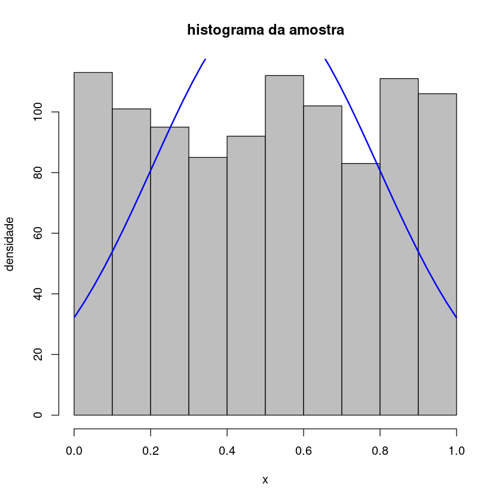

```r
# Geração de dados normais

x <- runif(1000)
h<-hist(x, breaks=10, col="gray", xlab="x", ylab="densidade",main="histograma da amostra")
xfit<-seq(min(x),max(x),length=40)
yfit<-dnorm(xfit,mean=mean(x),sd=sd(x))
yfit <- yfit*diff(h$mids[1:2])*length(x)
lines(xfit, yfit, col="blue", lwd=2)
```

1. 20

2. 46

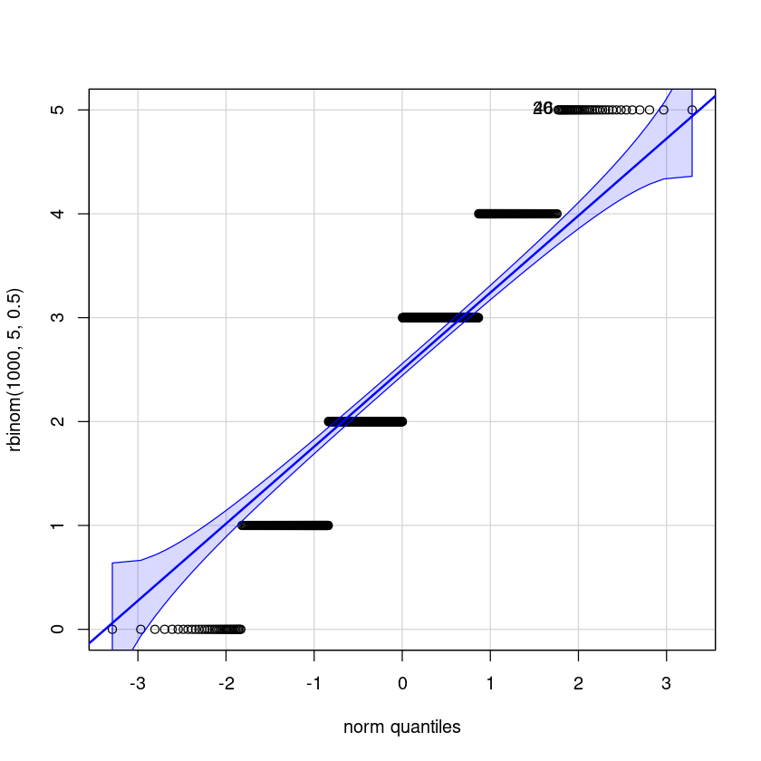

```r
car::qqPlot(rbinom(1000,5,0.5))
```